# Regression Models Course Project - Transmission effect on car MPG performance

Henrique Souza (github.com/htssouza)

# Executive Summary

Motor Trend Magazine is interested in exploring the relationship between a set of variables and miles per gallon (MPG). They are particularly interested in the following two questions:

1. Is an automatic or manual transmission better for MPG.
2. Quantify the MPG difference between automatic and manual transmissions.

In this document we compare different models and show that *for an average car, manual transmission outperforms automatic in **11%** MPG efficience*.

# Data Analysis

How our dataset looks like:

```
## 'data.frame':    32 obs. of  11 variables:
##  $ mpg : num  21 21 22.8 21.4 18.7 18.1 14.3 24.4 22.8 19.2 ...
##  $ cyl : num  6 6 4 6 8 6 8 4 4 6 ...
##  $ disp: num  160 160 108 258 360 ...
##  $ hp  : num  110 110 93 110 175 105 245 62 95 123 ...
##  $ drat: num  3.9 3.9 3.85 3.08 3.15 2.76 3.21 3.69 3.92 3.92 ...
##  $ wt  : num  2.62 2.88 2.32 3.21 3.44 ...
##  $ qsec: num  16.5 17 18.6 19.4 17 ...
##  $ vs  : num  0 0 1 1 0 1 0 1 1 1 ...
##  $ am  : Factor w/ 2 levels "auto","manual": 2 2 2 1 1 1 1 1 1 1 ...
##  $ gear: num  4 4 4 3 3 3 3 4 4 4 ...
##  $ carb: num  4 4 1 1 2 1 4 2 2 4 ...
```

MPG distribution by Transmission:

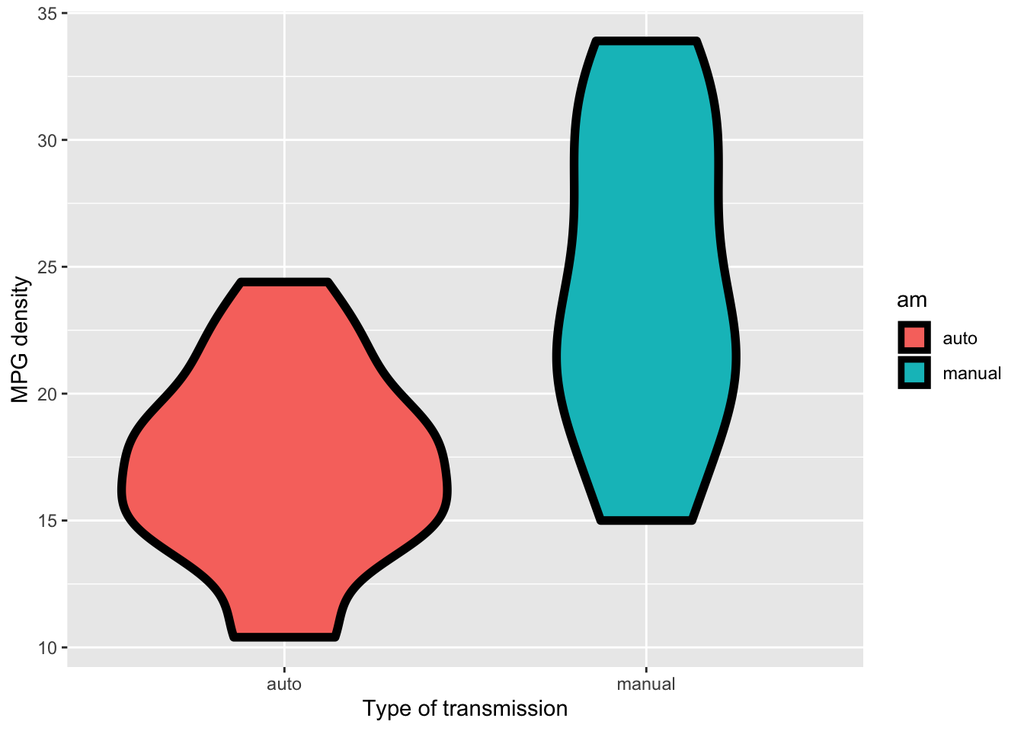

# Models

Based on the understanding of the dataset and the variables pairs plot (see Appendix), the following models were selected for comparison:

1. Using only the Transmission.
2. Transmission and Weight.
3. Transmission, Weight and HP
4. Transmission, Weight, HP and Displacement.
5. Transmission, Weight, HP, Displacement and Gears.

We will be using linear models as MPG is not a binary or a count variable.

Fitting our models:

```r
mod1 <- lm(mpg ~ am, data = mtcars)
mod2 <-  lm(mpg ~ am + wt, data = mtcars)
mod3 <-  lm(mpg ~ am + wt + hp, data = mtcars)
mod4 <-  lm(mpg ~ am + wt + hp + disp, data = mtcars)
mod5 <-  lm(mpg ~ am + wt + hp + disp + gear, data = mtcars)
```

# Model selection

Using anova function to compare models:

```r
anova(mod1, mod2, mod3, mod4, mod5)
```

```
## Analysis of Variance Table
##
## Model 1: mpg ~ am
## Model 2: mpg ~ am + wt
## Model 3: mpg ~ am + wt + hp
## Model 4: mpg ~ am + wt + hp + disp
## Model 5: mpg ~ am + wt + hp + disp + gear
##   Res.Df    RSS Df Sum of Sq       F    Pr(>F)
## 1     30 720.90
## 2     29 278.32  1    442.58 64.6717 1.604e-08 ***
## 3     28 180.29  1     98.03 14.3245 0.0008175 ***
## 4     27 179.91  1      0.38  0.0560 0.8147318
## 5     26 177.93  1      1.98  0.2891 0.5953915
## ---
## Signif. codes:  0 '***' 0.001 '**' 0.01 '*' 0.05 '.' 0.1 ' ' 1
```

The p-values for Model 4 is already too big (>= 0.05). We will stick with Model 3.

# Residual Analsysis

Plotting the residuals for our choosen model:

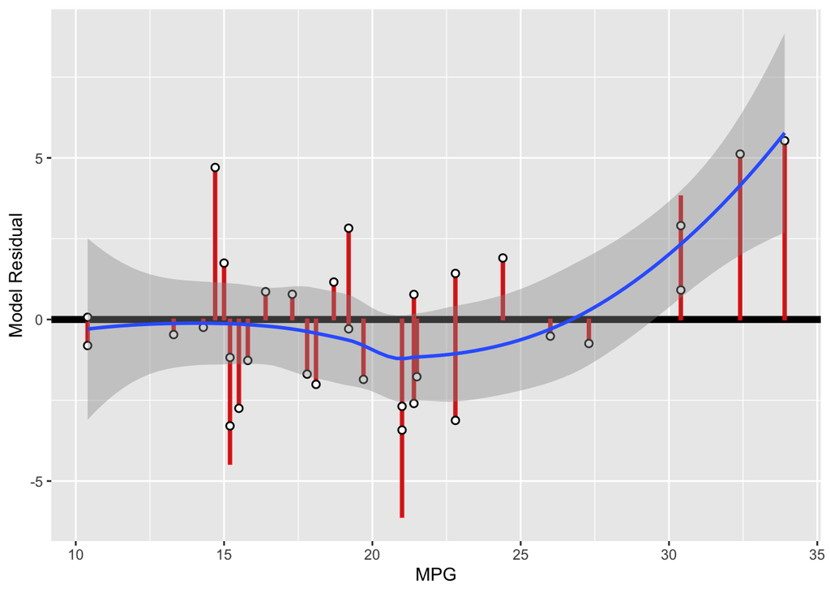

# Conclusion

Using our model to compare the performance of average cars with both transmission types we have that a *Manual* one has a better MPG performance of:

```
## 11 %
```

# Appendix

Plotting all variable pairs (linear model fitting lines):

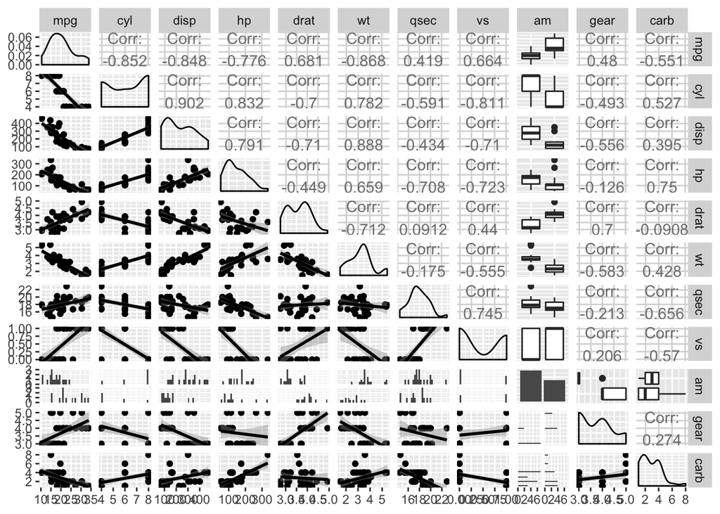

Plotting variable pairs used in our model (linear model fitting lines):

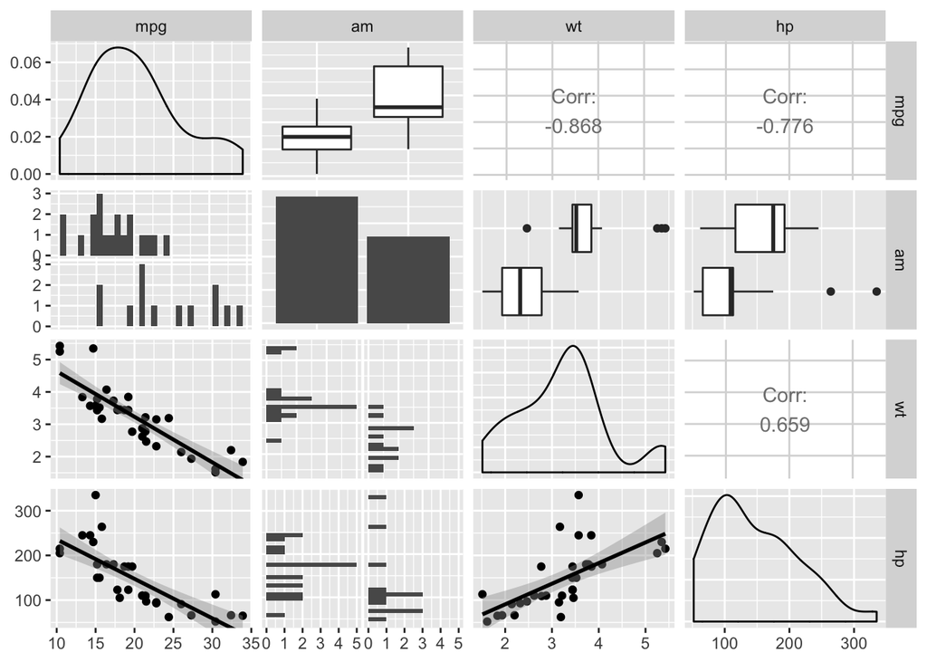